## Quality Control

We can look at the sum of each column and observe its library size. Next we can look for those genes that have very low gene counts because this will effect our analysis downstream. Once we see how many low expressed genes we have we will filter out those genes that have too few reads. We will keep genes that have at least 1 read per million in at least 3 samples

```r
colSums( counts ) # Library Sizes
```

```
## Baseline1 Baseline2 Baseline3 Infected1 Infected2 Infected3
##  12473885  14269056   7946328  13337869  10639409  15498396
```

```r
colSums( counts ) / 1e06 # Library Sizes in millions of reads
```

```
## Baseline1 Baseline2 Baseline3 Infected1 Infected2 Infected3
##    12.474    14.269     7.946    13.338    10.639    15.498
```

```r
table( rowSums( counts ) )[ 1:30 ] # Number of genes with low counts
```

```
##
## 60 61 62 63 64 65 66 67 68 69 70 71 72 73 74 75 76 77 78 79 80 81 82 83 84
## 36 38 26 33 24 27 29 42 37 40 28 39 29 26 28 17 34 34 28 23 30 13 26 18 29
## 85 86 87 88 89
## 33 21 17 28 24
```

```r
head( counts )
```

```
##                    Baseline1 Baseline2 Baseline3 Infected1 Infected2
## ENSMMUG00000000001        43        49        14       142       100
## ENSMMUG00000000005       548       497       288       389       240
## ENSMMUG00000000007       113       150        70        85        34
## ENSMMUG00000000009     36308     44236     13984     41337     27512
## ENSMMUG00000000010       447       383       157       338       349
## ENSMMUG00000000012       766       908       592       178       127
##                    Infected3
## ENSMMUG00000000001       121
## ENSMMUG00000000005       319
## ENSMMUG00000000007        44
## ENSMMUG00000000009     51502
## ENSMMUG00000000010       444
## ENSMMUG00000000012        98
```

```r
group <- c(rep("Baseline", 3) , rep("Infected", 3))
cds <- DGEList( counts , group = group )
names( cds )
```

```
## [1] "counts"  "samples"
```

```r
head(cds$counts) # original count matrix
```

```
##                    Baseline1 Baseline2 Baseline3 Infected1 Infected2
## ENSMMUG00000000001        43        49        14       142       100
## ENSMMUG00000000005       548       497       288       389       240
## ENSMMUG00000000007       113       150        70        85        34
## ENSMMUG00000000009     36308     44236     13984     41337     27512
## ENSMMUG00000000010       447       383       157       338       349
## ENSMMUG00000000012       766       908       592       178       127
##                    Infected3
## ENSMMUG00000000001       121
## ENSMMUG00000000005       319
## ENSMMUG00000000007        44
## ENSMMUG00000000009     51502
## ENSMMUG00000000010       444
## ENSMMUG00000000012        98
```

```r
cds$samples # contains a summary of your samples
```

```
##              group lib.size norm.factors
## Baseline1 Baseline 12473885            1
## Baseline2 Baseline 14269056            1
## Baseline3 Baseline  7946328            1
## Infected1 Infected 13337869            1
## Infected2 Infected 10639409            1
## Infected3 Infected 15498396            1
```

```r
sum( cds$all.zeros ) # How many genes have 0 counts across all samples
```

```
## [1] 0
```

## Normalization

We calculate normalization factors and effective libraries sizes. Normalization factors correct for the di???erences within the samples. Normalization factors are then multipled by the e???ective library size and the product becomes the library size which are displayed in the table below.

```r
cds <- cds[rowSums(1e+06 * cds$counts/expandAsMatrix(cds$samples$lib.size, dim(cds)) > 1) >= 3, ]
dim( cds )
```

```
## [1] 11906     6
```

```r
cds <- calcNormFactors( cds )
cds$samples
```

```
##              group lib.size norm.factors
## Baseline1 Baseline 12473885       1.1093
## Baseline2 Baseline 14269056       1.0097
## Baseline3 Baseline  7946328       0.8625
## Infected1 Infected 13337869       1.0184
## Infected2 Infected 10639409       1.1271
## Infected3 Infected 15498396       0.9019
```

```r
# effective library sizes
library_sizes <- cds$samples$lib.size * cds$samples$norm.factors

head(library_sizes)
```

```
## [1] 13837539 14407313  6853571 13583004 11991518 13977368
```

## Dimensionality Reduction

Lets make a MDS plot(like a PCA) this will take all my now normalized counts and plot them in geometric space to look at relationship between the conditions, how well my replicates bind together, and how much variability exists between my samples and conditions.

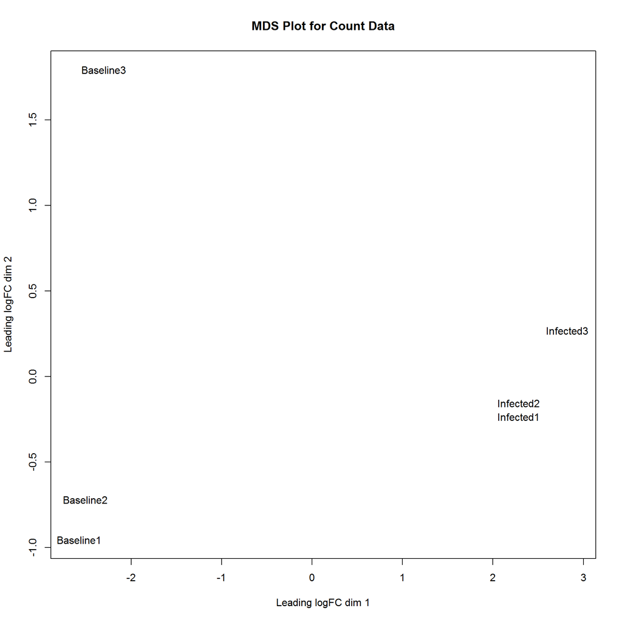

[output not shown]

[output not shown]

[output not shown]

[output not shown]

[output not shown]

[output not shown]

[output not shown]

[output not shown]

```r
plotMDS( cds , main = "MDS Plot for Count Data", labels = colnames( cds$counts ) )
```

## Mean Variance Plot

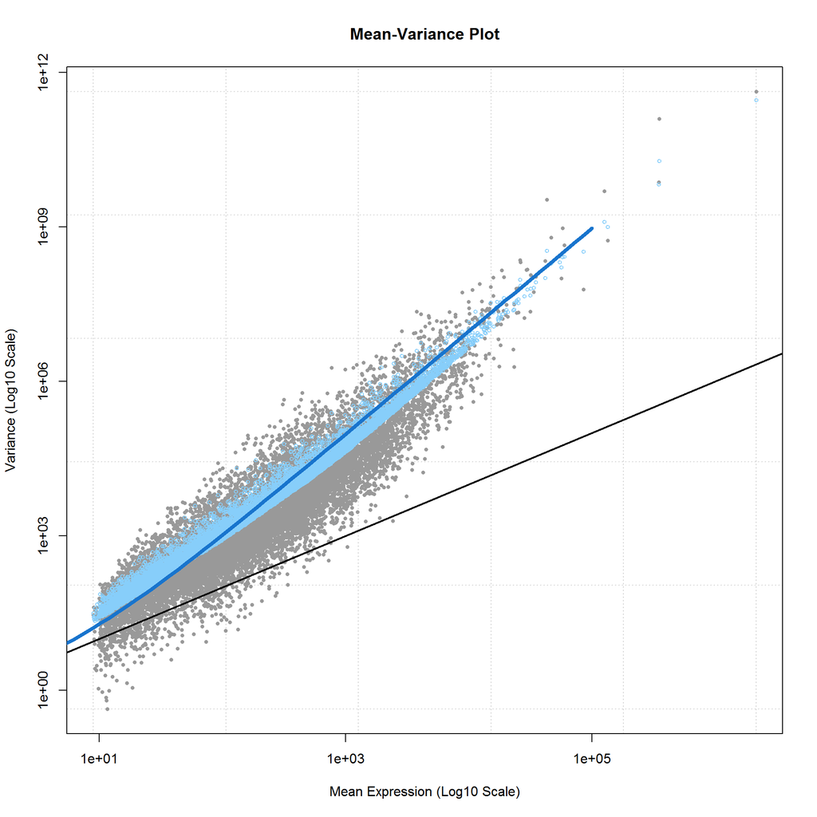

```r
plotMeanVar( cds , show.raw.vars=TRUE ,
show.tagwise.vars=TRUE ,
show.binned.common.disp.vars=FALSE ,
show.ave.raw.vars=FALSE ,
NBline = TRUE ,
nbins = 100 ,
pch = 16 ,
xlab ="Mean Expression (Log10 Scale)" ,
ylab = "Variance (Log10 Scale)" ,
main = "Mean-Variance Plot" )
```

## Differential Expression

```r
de.cmn <- exactTest( cds , dispersion="common" , pair = c("Baseline" , "Infected" ) )
de.tgw <- exactTest( cds , dispersion="common" , pair = c("Baseline" , "Infected" ) )
de.poi <- exactTest( cds , dispersion = 1e-06 , pair = c("Baseline" , "Infected" ) )
names( de.tgw )
```

```
## [1] "table"      "comparison" "genes"
```

```r
de.tgw$comparison # which groups have been compared
```

```
## [1] "Baseline" "Infected"
```

```r
head( de.tgw$table ) # results table in order of your count matrix.
```

```
##                      logFC logCPM    PValue
## ENSMMUG00000000001  1.6538  2.637 4.273e-05
## ENSMMUG00000000005 -0.6987  4.972 5.957e-02
## ENSMMUG00000000007 -1.2272  2.799 1.922e-03
## ENSMMUG00000000009  0.2221 11.448 5.419e-01
## ENSMMUG00000000010  0.0661  4.813 8.590e-01
## ENSMMUG00000000012 -2.7351  5.295 4.086e-12
```

```r
head( cds$counts )
```

```
##                    Baseline1 Baseline2 Baseline3 Infected1 Infected2
## ENSMMUG00000000001        43        49        14       142       100
## ENSMMUG00000000005       548       497       288       389       240
## ENSMMUG00000000007       113       150        70        85        34
## ENSMMUG00000000009     36308     44236     13984     41337     27512
## ENSMMUG00000000010       447       383       157       338       349
## ENSMMUG00000000012       766       908       592       178       127
##                    Infected3
## ENSMMUG00000000001       121
## ENSMMUG00000000005       319
## ENSMMUG00000000007        44
## ENSMMUG00000000009     51502
## ENSMMUG00000000010       444
## ENSMMUG00000000012        98
```

```r
options( digits = 3 ) # print only 3 digits
topTags( de.tgw , n = 20 , sort.by = "p.value" ) # top 20 DE genes
```

```
## Comparison of groups:  Infected-Baseline
##                    logFC logCPM   PValue      FDR
## ENSMMUG00000002657 10.54  11.80 7.04e-82 8.38e-78
## ENSMMUG00000004489  9.10   9.82 6.61e-68 3.93e-64
## ENSMMUG00000012535 10.12   7.01 1.03e-65 4.07e-62
## ENSMMUG00000010927 10.21   7.20 4.05e-65 1.21e-61
## ENSMMUG00000021062  9.07   7.88 2.74e-61 6.52e-58
## ENSMMUG00000006765 13.36   5.73 7.37e-60 1.46e-56
## ENSMMUG00000000672  8.92   6.80 7.43e-59 1.24e-55
## ENSMMUG00000007176  8.21   8.48 8.85e-59 1.24e-55
## ENSMMUG00000020176  9.21   6.41 9.41e-59 1.24e-55
## ENSMMUG00000015091  8.01   9.98 2.71e-58 3.22e-55
## ENSMMUG00000022070  8.50   7.25 9.75e-58 1.06e-54
## ENSMMUG00000031200  8.39   7.44 2.49e-57 2.48e-54
## ENSMMUG00000017637 12.95   5.32 5.07e-56 4.64e-53
## ENSMMUG00000008680 11.14   5.44 5.70e-56 4.84e-53
## ENSMMUG00000000288 12.61   4.98 7.80e-53 6.19e-50
## ENSMMUG00000002200  7.79   6.79 9.55e-53 7.11e-50
## ENSMMUG00000007917 10.74   5.05 2.92e-52 2.04e-49
## ENSMMUG00000015969  7.35   8.82 2.72e-51 1.80e-48
## ENSMMUG00000007263  8.35   5.68 2.94e-51 1.84e-48
## ENSMMUG00000002467  8.03   5.88 4.59e-51 2.73e-48
```

```r
# Back to count matrix for tagwise analysis
cds$counts[ rownames( topTags( de.tgw , n = 15 )$table ) , ]
```

```
##                    Baseline1 Baseline2 Baseline3 Infected1 Infected2
## ENSMMUG00000002657        43        85        37     33444     47170
## ENSMMUG00000004489        55        52        14     28162     17836
## ENSMMUG00000012535         3         5         0      2729      2534
## ENSMMUG00000010927         4         0         4      6485       875
## ENSMMUG00000021062         0         5        20      1955      4923
## ENSMMUG00000006765         0         0         0      1103      1136
## ENSMMUG00000000672         6         8         2      3504      1147
## ENSMMUG00000007176        24        46        15     10119      8737
## ENSMMUG00000020176         7         3         0      1618      1451
## ENSMMUG00000015091        93       100        68     17366     18912
## ENSMMUG00000022070        15         8         6      2979      4867
## ENSMMUG00000031200        12        11        11      3658      2776
## ENSMMUG00000017637         0         0         0       732       849
## ENSMMUG00000008680         0         1         0       776      1070
## ENSMMUG00000000288         0         0         0      1049       300
##                    Infected3
## ENSMMUG00000002657    209542
## ENSMMUG00000004489     25970
## ENSMMUG00000012535      5018
## ENSMMUG00000010927      4620
## ENSMMUG00000021062     11960
## ENSMMUG00000006765      1956
## ENSMMUG00000000672      4376
## ENSMMUG00000007176      9245
## ENSMMUG00000020176      3744
## ENSMMUG00000015091     44676
## ENSMMUG00000022070      3997
## ENSMMUG00000031200      7479
## ENSMMUG00000017637      1583
## ENSMMUG00000008680      1580
## ENSMMUG00000000288      1197
```

```r
# Sort tagwise results by Fold-Change instead of p-value
resultsByFC.tgw <- topTags( de.tgw , n = nrow( de.tgw$table ) , sort.by = "logFC" )$table
head( resultsByFC.tgw )
```

```
##                    logFC logCPM   PValue      FDR
## ENSMMUG00000006765  13.4   5.73 7.37e-60 1.46e-56
## ENSMMUG00000017637  12.9   5.32 5.07e-56 4.64e-53
## ENSMMUG00000000288  12.6   4.98 7.80e-53 6.19e-50
## ENSMMUG00000008680  11.1   5.44 5.70e-56 4.84e-53
## ENSMMUG00000000984  11.0   3.36 9.71e-38 1.70e-35
## ENSMMUG00000007917  10.7   5.05 2.92e-52 2.04e-49
```

```r
# Store full topTags results table
resultsTbl.cmn <- topTags( de.cmn , n = nrow( de.cmn$table ) )$table
resultsTbl.tgw <- topTags( de.tgw , n = nrow( de.tgw$table ) )$table
resultsTbl.poi <- topTags( de.poi , n = nrow( de.poi$table ) )$table

# Names/IDs of DE genes
de.genes.cmn <- rownames( resultsTbl.cmn )[ resultsTbl.cmn$adj.P.Val <= 0.05 ]
de.genes.tgw <- rownames( resultsTbl.tgw )[ resultsTbl.tgw$adj.P.Val <= 0.05 ]
de.genes.poi <- rownames( resultsTbl.poi )[ resultsTbl.poi$adj.P.Val <= 0.05 ]

summary( decideTestsDGE( de.tgw , p.value = 0.05 ) )
```

```
##    [,1]
## -1 3258
## 0  5554
## 1  3094
```

```r
count_results_sorted <- cds$counts[ rownames( topTags( de.tgw , n = 30246 )$table ) , ]


colnames( resultsTbl.cmn ) <- c( "logConc" , "logFC" , "pVal.Cmn" , "adj.pVal.Cmn" )

colnames( resultsTbl.tgw ) <- c( "logConc" , "logFC" , "pVal.Tgw" , "adj.pVal.Tgw" )

#If we'd like, we could just write these tables to a file

#write.table(resultsTbl.cmn, file="${fileout:de_results}", sep = "\t",qmethod = "double", col.names=TRUE)


#write.table(resultsTbl.tgw, file = "${fileout:de_results}", sep = "\t",qmethod = "double", col.names=TRUE)
```